# Zad3_RyzykoOperacyjny

## 5.4 Symulacja

Symulacja metodą Monte Carlo bazująca na dwóch wcześniej wybranych rozkładach - ujemnym dwumianowy oraz gamma.

**Show and hide code**

```r
nbinom_params3 <- Empl_Pract_fit$estimate
size_param3 <- nbinom_params3["size"]
mu_param3 <- nbinom_params3["mu"]

gamma_params3 <- Empl_Pract4$estimate
shape_param3 <- gamma_params3["shape"]
rate_param3 <- gamma_params3["rate"]
```

Parametry dla rozkładu ujemno-dwumianowgo:  
size = 255.11  
mu = 213.54

Parametry dopasowania gamma:  
shape = 1.092585e+02  
rate = 1.461848e-05

Symulujemy 20000 scenariuszy rocznych strat. Do każdej symulacji wylosowano liczbę zdarzeń z rozkładu ujemnego-dwumianowego oraz straty dla każdej szkody z rozkładu gamma.

**Show and hide code**

```r
n_sim <- 20000

symulacje_Empl_Pract <- replicate(n_sim, {
  liczba_zdarzen <- rnbinom(1, size = size_param3, mu = mu_param3)
  if (liczba_zdarzen == 0) return(0)
  sum(rgamma(liczba_zdarzen, shape = shape_param3, rate = rate_param3))
})
```

Następnie na podstawie rozkładu symulowanego obliczamy OpVaR(99.9%) oraz OpES(99.9%).

**Show and hide code**

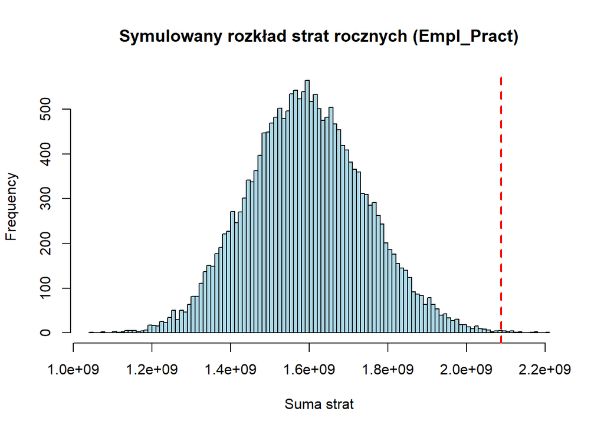

```r
OpVaR_999_Empl_Pract <- quantile(symulacje_Empl_Pract, 0.999)
OpES_999_Empl_Pract <- mean(symulacje_Empl_Pract[symulacje_Empl_Pract > OpVaR_999_Empl_Pract])

hist_Empl_Pract <- hist(symulacje_Empl_Pract, breaks = 100, col = "lightblue",
     main = "Symulowany rozkład strat rocznych (Empl_Pract)",
     xlab = "Suma strat")
abline(v = OpVaR_999_Empl_Pract, col = "red", lwd = 2, lty = 2)
```

**Show and hide code**

```r
# Wyniki
cat("OpVaR (99.9%) = ", OpVaR_999_Empl_Pract, "\n")
```

```
OpVaR (99.9%) =  2087657615
```

**Show and hide code**

```r
cat("OpES  (99.9%) = ", OpES_999_Empl_Pract, "\n")
```

```
OpES  (99.9%) =  2122266963
```

Histogram symulowanego rozkładu strat, a na nim zaznaczona jest wartość OpVaR. Na osi X mamy wielkość straty, a na osi Y częstotliwość tych strat. Większość strat wynosi ok. 1.6e+09. Rozkład jest bardzo zbliżony do normalnego oraz posiada największe do tej pory wielkości strat zachowujac umiarkowaną częstotliwość ich występowania co do roku.

# 6 linia Execut_Del

## 6.1 Rozkład częstotliwości

**Show and hide code**

```r
rok_Execut_Del <- plik28 |>
  filter( linia == "Execut_Del") |>
  group_by(rok) |>
  summarize(liczba_zdarzen = n())

straty_Execut_Del <- plik28 |>
  filter(linia == "Execut_Del") |>
  group_by(rok) |>
  summarize(straty = sum(strata, na.rm = TRUE))

Exe_summary <- merge(rok_Execut_Del, straty_Execut_Del, by = "rok")

kable(Exe_summary, format = "html", caption = "Podsumowanie dla liniii Execut_Del") |>
  kable_styling(bootstrap_options = c("striped", "hover", "condensed"), full_width = F)
```

Podsumowanie dla liniii Execut_Del

| rok | liczba_zdarzen | straty |
| --- | --- | --- |
| 1989 | 7 | 32443.98 |
| 1990 | 8 | 25183.74 |
| 1991 | 8 | 36884.32 |
| 1992 | 8 | 42530.23 |
| 1993 | 6 | 24862.21 |
| 1994 | 7 | 50147.97 |
| 1995 | 11 | 39118.74 |
| 1996 | 7 | 31436.57 |
| 1997 | 11 | 47792.31 |
| 1998 | 10 | 65092.97 |
| 1999 | 6 | 53997.87 |
| 2000 | 6 | 25331.74 |
| 2001 | 9 | 34157.58 |
| 2002 | 8 | 49609.51 |
| 2003 | 3 | 14570.33 |
| 2004 | 7 | 27330.12 |
| 2005 | 9 | 53641.67 |
| 2006 | 3 | 24377.01 |
| 2007 | 7 | 69900.33 |
| 2008 | 8 | 31655.42 |
| 2009 | 6 | 13286.27 |
| 2010 | 9 | 60221.61 |
| 2011 | 4 | 15170.91 |
| 2012 | 8 | 101401.60 |
| 2013 | 10 | 29411.31 |
| 2014 | 6 | 20597.15 |
| 2015 | 4 | 3862.68 |
| 2016 | 2 | 5578.95 |
| 2017 | 4 | 29163.78 |
| 2018 | 6 | 41408.76 |
| 2019 | 6 | 22235.76 |
| 2020 | 8 | 18000.05 |
| 2021 | 10 | 47766.96 |
| 2022 | 7 | 38916.71 |
| 2023 | 10 | 63781.09 |

Dane zostały przefiltrowane dla liniii Execut_Del. Dla każdego roku obliczono liczbę zdarzeń oraz sumę strat.

**Show and hide code**

```r
mean_Execut_Del = mean(rok_Execut_Del$liczba_zdarzen)
sd_Execut_Del = sd(rok_Execut_Del$liczba_zdarzen)

mean_Execut_Del
```

```
[1] 7.114286
```

**Show and hide code**

```r
sd_Execut_Del
```

```
[1] 2.285136
```

Średnia liczba zdarzeń to 7.11 a odchylenie standardowe 2.28. Na tej podstawie dopasowujemy rozkład dwumianowy, ponieważ gdy E(X) > D^2(X).

## 6.2 Rozkład zdarzeń

Przyporządkowaliśmy rozkład dwumianowy. Dla pewności, sprawdźmy jeszcze dopasowanie funkcją “fitdistr”:

**Show and hide code**

```r
Execut_Del_fit <- fitdist(rok_Execut_Del$liczba_zdarzen, "binom",fix.arg = list(size = size_value))
gofstat(Execut_Del_fit)
```

```
Chi-squared statistic:  2.51222
Degree of freedom of the Chi-squared distribution:  4
Chi-squared p-value:  0.642449
   the p-value may be wrong with some theoretical counts < 5
Chi-squared table:
      obscounts theocounts
<= 4   6.000000   5.353694
<= 6   7.000000   9.583432
<= 7   6.000000   5.402099
<= 8   7.000000   4.809904
<= 10  7.000000   6.390578
> 10   2.000000   3.460294

Goodness-of-fit criteria
                               1-mle-binom
Akaike's Information Criterion    160.3428
Bayesian Information Criterion    161.8981
```

p-value wynosi 0,64 z tego powodu nie ma podstaw do odrzucenia hipotezy zerowej i możemy uznać rozkład dwumianowy za dobrze dopasowany. Dla pewności zobaczymy to jeszcze na wykresie:

**Show and hide code**

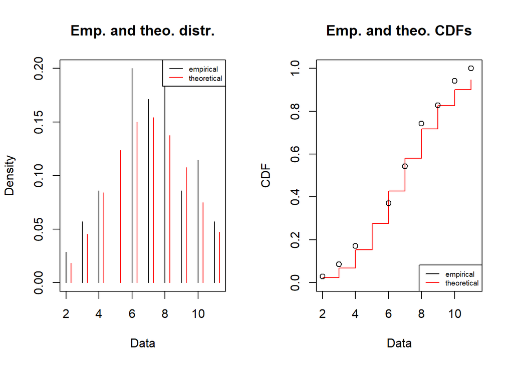

```r
plot(Execut_Del_fit)
```

## 6.3 Rozkład strat

Będziemy sprawdzać dopasowanie funkcją fitdist, sprawdzamy dopasowanie rozkładu dotkliwości strat do rozkładów weibull, lnorm, exp oraz gamma. Dopasowanie metodą momentów (mme).

**Show and hide code**

```r
Execut_Del1 <- fitdist(straty_Execut_Del$straty, "weibull")
Execut_Del2 <- fitdist(straty_Execut_Del$straty, method="mme","lnorm")
Execut_Del3 <- fitdist(straty_Execut_Del$straty, method="mme","exp")
Execut_Del4 <- fitdist(straty_Execut_Del$straty, method="mme","gamma")
names_test = c("Weibull","lnorm", "exp", "gamma")

Result_Execut_Del<-gofstat(list(Execut_Del1, Execut_Del2,Execut_Del3,Execut_Del4), fitnames=names_test)
Result_Execut_Del$chisqpvalue
```

```
    Weibull       lnorm         exp       gamma
0.422689954 0.084694624 0.001264509 0.348492633
```

**Show and hide code**

```r
Result_Execut_Del$adtest
```

```
       Weibull          lnorm            exp          gamma
"not rejected" "not computed" "not computed" "not computed"
```

**Show and hide code**

```r
Result_Execut_Del$kstest
```

```
       Weibull          lnorm            exp          gamma
"not rejected" "not rejected"     "rejected" "not rejected"
```

Tylko w przypadku kstest exp zostało odrzucone, reszta nieodrzucona. Z tego powodu zobaczmy to na wykresie.

- Dla weibull:

**Show and hide code**

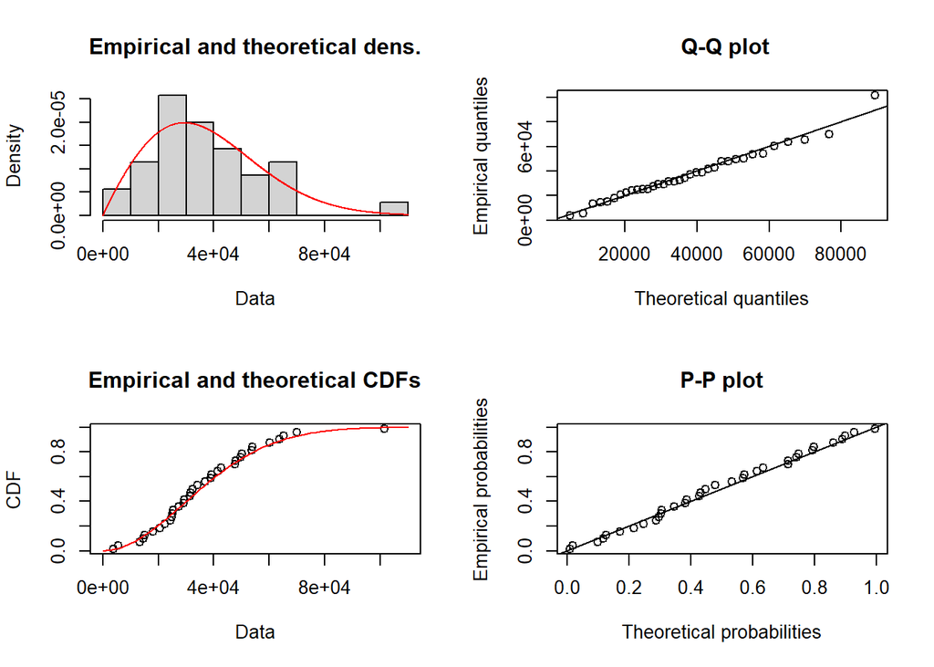

```r
plot(fitdist(straty_Execut_Del$straty, "weibull"))
```

- Dla gammy:

**Show and hide code**

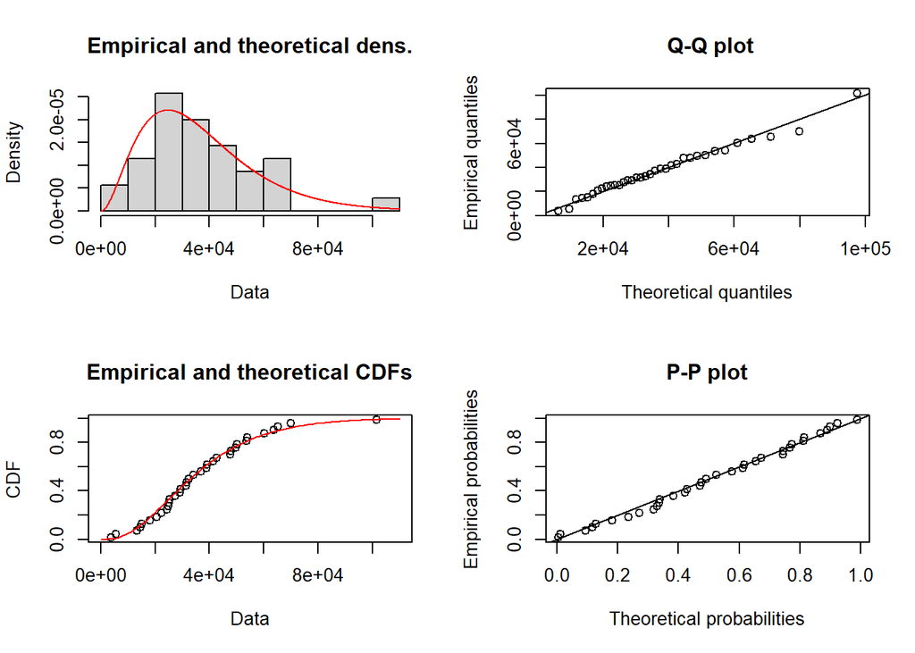

```r
plot(fitdist(straty_Execut_Del$straty, "gamma"))
```

Wybieramy dopasowanie do rozkładu weibulla.

## 6.4 Symulacja

**Show and hide code**

```r
set.seed(123)

binom_params_exec <- Execut_Del_fit$estimate
prob_param_exec <- binom_params_exec["prob"]


weibull_params_exec <- Execut_Del1$estimate
shape_exec <- weibull_params_exec["shape"]
scale_exec <- weibull_params_exec["scale"]
```

Parametry dopasowania weibulla:  
shape = 1.95  
scale = 42473.57

Symulujemy 20000 scenariuszy rocznych strat. Do każdej symulacji wylosowano liczbę zdarzeń z rozkładu dwumianowego oraz straty dla każdej szkody z rozkładu weibulla.

**Show and hide code**

```r
n_sim <- 20000
size_param_binom <- 100

symulacje_Execut_Del <- replicate(n_sim, {
  liczba_zdarzen <- rbinom(1, size = size_param_binom, prob = prob_param_exec)
  if (liczba_zdarzen == 0) return(0)
  sum(rweibull(liczba_zdarzen, shape = shape_exec, scale = scale_exec))
})
```

Następnie na podstawie rozkładu symulowanego obliczamy OpVaR(99.9%) oraz OpES(99.9%).

**Show and hide code**

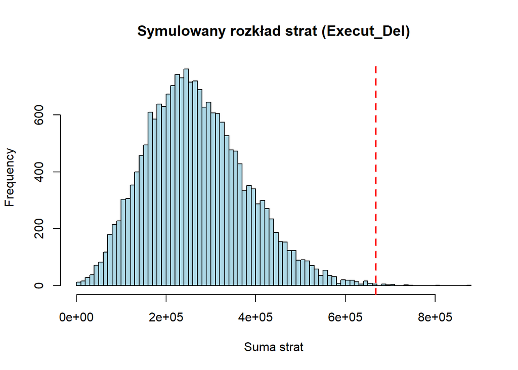

```r
OpVaR_999_Execut_Del <- quantile(symulacje_Execut_Del, 0.999)
OpES_999_Execut_Del <- mean(symulacje_Execut_Del[symulacje_Execut_Del > OpVaR_999_Execut_Del])

hist_Execut_Del <- hist(symulacje_Execut_Del, breaks = 100, col = "lightblue",
     main = "Symulowany rozkład strat (Execut_Del)", xlab = "Suma strat")
abline(v = OpVaR_999_Execut_Del, col = "red", lwd = 2, lty = 2)
```

**Show and hide code**

```r
cat("OpVaR (99.9%) = ", OpVaR_999_Execut_Del, "\n")
```

```
OpVaR (99.9%) =  667818.2
```

**Show and hide code**

```r
cat("OpES  (99.9%) = ", OpES_999_Execut_Del, "\n")
```

```
OpES  (99.9%) =  717884.6
```

Histogram symulowanego rozkładu strat, a na nim zaznaczona jest wartość OpVaR. Na osi X mamy wielkość straty, a na osi Y częstotliwość tych strat. Większość strat wynosi ok. 2e+05.Rozkład jest znacznie prawoskośny. Straty są umiarkowanie dotkliwe.

# 7 linia External_Fr

## 7.1 Rozkład częstotliwości

**Show and hide code**

```r
rok_External_Fr <- plik28 |>
  filter( linia == "External_Fr") |>
  group_by(rok) |>
  summarize(liczba_zdarzen = n())


straty_External_Fr <- plik28 |>
  filter(linia == "External_Fr") |>
  group_by(rok) |>
  summarize(straty = sum(strata, na.rm = TRUE))


Ext_summary <- merge(rok_External_Fr, straty_External_Fr, by = "rok")

kable(Ext_summary, format = "html", caption = "Podsumowanie dla liniii External_Fr") |>
  kable_styling(bootstrap_options = c("striped", "hover", "condensed"), full_width = F)
```

Podsumowanie dla liniii External_Fr

| rok | liczba_zdarzen | straty |
| --- | --- | --- |
| 1989 | 12 | 32166.49 |
| 1990 | 13 | 63423.79 |
| 1991 | 8 | 29435.65 |
| 1992 | 11 | 37569.00 |
| 1993 | 8 | 22289.56 |
| 1994 | 13 | 52008.49 |
| 1995 | 12 | 29850.18 |
| 1996 | 8 | 52516.61 |
| 1997 | 9 | 43796.27 |
| 1998 | 13 | 19173.35 |
| 1999 | 12 | 21765.85 |
| 2000 | 14 | 51806.49 |
| 2001 | 11 | 34493.84 |
| 2002 | 9 | 15241.18 |
| 2003 | 10 | 28876.84 |
| 2004 | 11 | 13422.37 |
| 2005 | 12 | 30643.62 |
| 2006 | 11 | 74628.62 |
| 2007 | 13 | 30374.37 |
| 2008 | 11 | 60237.31 |
| 2009 | 7 | 22625.16 |
| 2010 | 13 | 43570.25 |
| 2011 | 10 | 24922.42 |
| 2012 | 15 | 59041.50 |
| 2013 | 13 | 34151.40 |
| 2014 | 8 | 17615.49 |
| 2015 | 15 | 42201.61 |
| 2016 | 8 | 23970.41 |
| 2017 | 14 | 38435.34 |
| 2018 | 13 | 57232.19 |
| 2019 | 10 | 21103.14 |
| 2020 | 12 | 25322.49 |
| 2021 | 6 | 5163.29 |
| 2022 | 14 | 34517.60 |
| 2023 | 13 | 28257.83 |

**Show and hide code**

```r
mean_External_Fr = mean(rok_External_Fr$liczba_zdarzen)
sd_External_Fr = sd(rok_External_Fr$liczba_zdarzen)
mean_External_Fr
```

```
[1] 11.2
```

**Show and hide code**

```r
sd_External_Fr
```

```
[1] 2.373877
```

Średnia liczba zdarzeń to 11.2 a odchylenie standardowe 2.37. Na tej podstawie dopasowujemy rozkład dwumianowy, ponieważ gdy E(X) > D^2(X).

## 7.2 Rozkład zdarzeń

Przyporządkowaliśmy rozkład dwumianowy. Dla pewności, sprawdźmy jeszcze dopasowanie funkcją “fitdistr”:

**Show and hide code**

```r
External_Fr_fit <- fitdist(rok_External_Fr$liczba_zdarzen, "binom",fix.arg = list(size = size_value))
gofstat(External_Fr_fit)
```

```
Chi-squared statistic:  8.143475
Degree of freedom of the Chi-squared distribution:  4
Chi-squared p-value:  0.08646167
   the p-value may be wrong with some theoretical counts < 5
Chi-squared table:
      obscounts theocounts
<= 8   7.000000   6.958887
<= 10  5.000000   8.013945
<= 11  5.000000   4.419505
<= 12  5.000000   4.134222
<= 13  8.000000   3.529754
> 13   5.000000   7.943687

Goodness-of-fit criteria
                               1-mle-binom
Akaike's Information Criterion    166.4750
Bayesian Information Criterion    168.0303
```

p-value wynosi 0,08 z tego powodu nie ma podstaw do odrzucenia hipotezy zerowej i możemy uznać rozkład dwumianowy za dobrze dopasowany. Dla pewności zobaczymy to jeszcze na wykresie:

**Show and hide code**

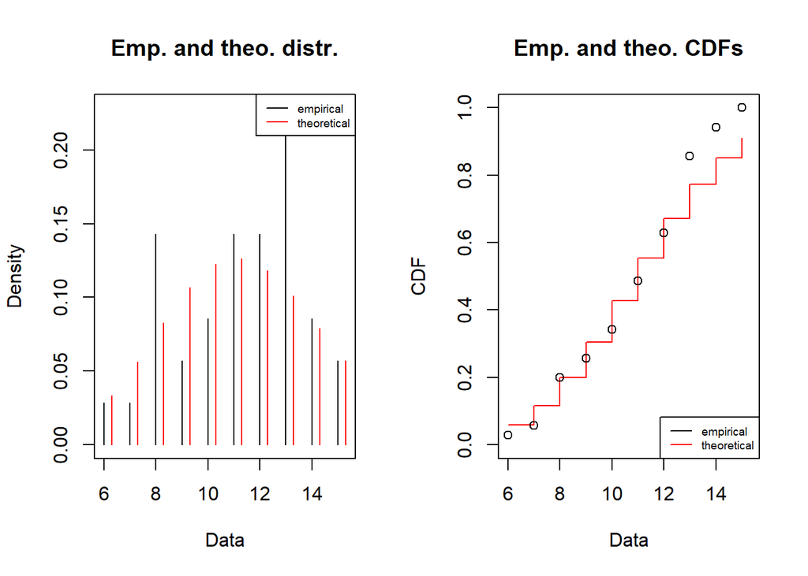

```r
plot(External_Fr_fit)
```

Po stosunkowo niskim p-value możnaby było spodziewać się sporych różnic między rozkładem empirycznym a teoretycznym. Jednak z braku lepszych opcji wybierzemy właśnie jego.

## 7.3 Rozkład strat

Będziemy sprawdzać dopasowanie funkcją fitdist, sprawdzamy dopasowanie rozkładu dotkliwości strat do rozkładów weibull, lnorm, exp oraz gamma. Dopasowanie metodą momentów (mme).

**Show and hide code**

```r
External_Fr1 <- fitdist(straty_External_Fr$straty, "weibull")
External_Fr2 <- fitdist(straty_External_Fr$straty, method="mme","lnorm")
External_Fr3 <- fitdist(straty_External_Fr$straty, method="mme","exp")
External_Fr4 <- fitdist(straty_External_Fr$straty, method="mme","gamma")
names_test = c("Weibull","lnorm", "exp", "gamma")

Result_External_Fr<-gofstat(list(External_Fr1, External_Fr2,External_Fr3,External_Fr4), fitnames=names_test)
Result_External_Fr$chisqpvalue
```

```
     Weibull        lnorm          exp        gamma
0.8228643380 0.9431443976 0.0007929586 0.9657633843
```

**Show and hide code**

```r
Result_External_Fr$adtest
```

```
       Weibull          lnorm            exp          gamma
"not rejected" "not computed" "not computed" "not computed"
```

**Show and hide code**

```r
Result_External_Fr$kstest
```

```
       Weibull          lnorm            exp          gamma
"not rejected" "not rejected"     "rejected" "not rejected"
```

Tylko w przypadku kstest exp zostało odrzucone, reszta nieodrzucona. Z tego powodu zobaczmy to na wykresie.

- Dla lnorm:

**Show and hide code**

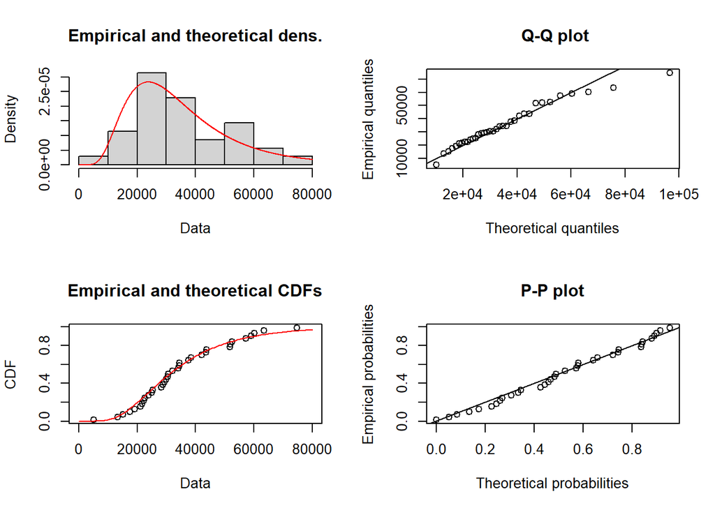

```r
plot(fitdist(straty_External_Fr$straty, "lnorm"))
```

- Dla gammy:

**Show and hide code**

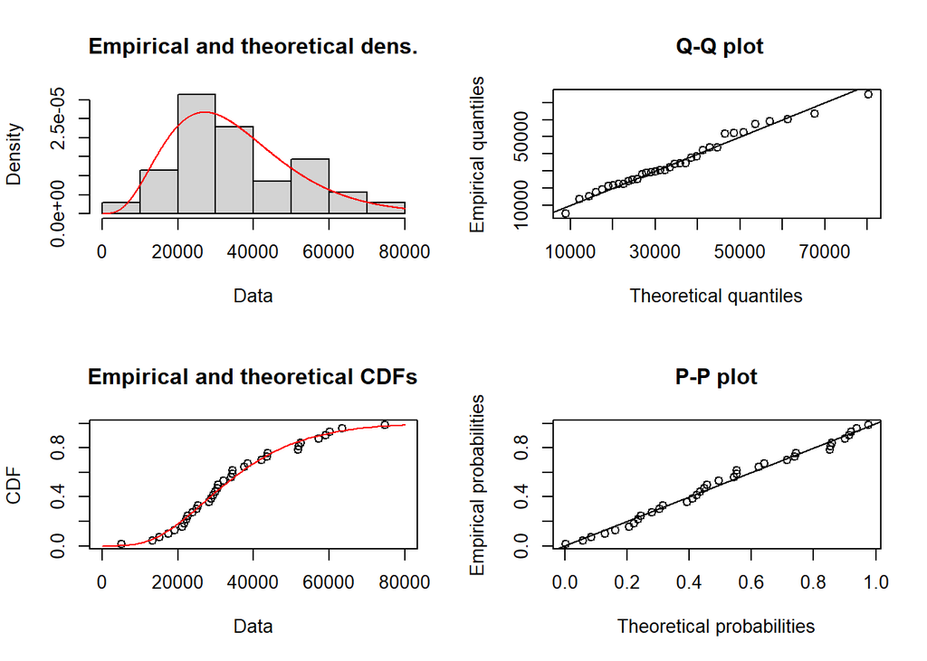

```r
plot(fitdist(straty_External_Fr$straty, "gamma"))
```

Wybieramy dopasowanie do rozkładu Lnorm.

## 7.4 Symulacja

Symulacja metodą Monte Carlo bazująca na dwóch wcześniej wybranych rozkładach - dwumianowy oraz Lnorm.

**Show and hide code**

```r
set.seed(123)

binom_params_ext <- External_Fr_fit$estimate
prob_param_ext <- binom_params_ext["prob"]

lnorm_params_ext <- External_Fr2$estimate
meanlog_ext <- lnorm_params_ext["meanlog"]
sdlog_ext <- lnorm_params_ext["sdlog"]
```

Parametry dla rozkładu dwumianowego:  
prob = 0.11

Parametry dopasowania Lnorm:  
meanlog = 10.37  
sdlog = 0.43

Symulujemy 20000 scenariuszy rocznych strat. Do każdej symulacji wylosowano liczbę zdarzeń z rozkładu dwumianowego oraz straty dla każdej szkody z rozkładu Lnorm.

**Show and hide code**

```r
symulacje_External_Fr <- replicate(n_sim, {
  liczba_zdarzen <- rbinom(1, size = size_param_binom, prob = prob_param_ext)
  if (liczba_zdarzen == 0) return(0)
  sum(rlnorm(liczba_zdarzen, meanlog = meanlog_ext, sdlog = sdlog_ext))
})
```

Następnie na podstawie rozkładu symulowanego obliczamy OpVaR(99.9%) oraz OpES(99.9%).

**Show and hide code**

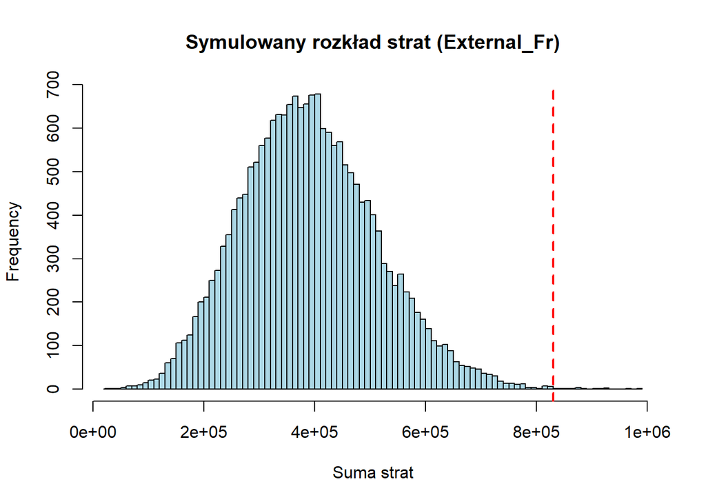

```r
OpVaR_999_External_Fr <- quantile(symulacje_External_Fr, 0.999)
OpES_999_External_Fr <- mean(symulacje_External_Fr[symulacje_External_Fr > OpVaR_999_External_Fr])

hist_External_Fr <- hist(symulacje_External_Fr, breaks = 100, col = "lightblue",
     main = "Symulowany rozkład strat (External_Fr)", xlab = "Suma strat")
abline(v = OpVaR_999_External_Fr, col = "red", lwd = 2, lty = 2)
```

**Show and hide code**

```r
cat("OpVaR (99.9%) = ", OpVaR_999_External_Fr, "\n")
```

```
OpVaR (99.9%) =  830351.2
```

**Show and hide code**

```r
cat("OpES  (99.9%) = ", OpES_999_External_Fr, "\n")
```

```
OpES  (99.9%) =  890326.5
```

Histogram symulowanego rozkładu strat, a na nim zaznaczona jest wartość OpVaR. Na osi X mamy wielkość straty, a na osi Y częstotliwość tych strat. Większość strat wynosi ok. 350000. Wykres jest lekko prawoskośny.

# 8 linia Internal_Fr

## 8.1 Rozkład częstotliwości

**Show and hide code**

```r
rok_Internal_Fr <- plik28 |>
  filter( linia == "Internal_Fr") |>
  group_by(rok) |>
  summarize(liczba_zdarzen = n())

straty_Internal_Fr <- plik28 |>
  filter(linia == "Internal_Fr") |>
  group_by(rok) |>
  summarize(straty = sum(strata, na.rm = TRUE))



Int_summary <- merge(rok_Internal_Fr, straty_Internal_Fr, by = "rok")

kable(Int_summary, format = "html", caption = "Podsumowanie dla liniii Internal_Fr") |>
  kable_styling(bootstrap_options = c("striped", "hover", "condensed"), full_width = F)
```

Podsumowanie dla liniii Internal_Fr

| rok | liczba_zdarzen | straty |
| --- | --- | --- |
| 1989 | 171 | 847021.5 |
| 1990 | 181 | 942235.5 |
| 1991 | 203 | 943501.6 |
| 1992 | 184 | 924506.4 |
| 1993 | 147 | 691429.8 |
| 1994 | 200 | 1027904.7 |
| 1995 | 183 | 935526.3 |
| 1996 | 182 | 887992.9 |
| 1997 | 173 | 945138.4 |
| 1998 | 193 | 1040888.0 |
| 1999 | 172 | 981989.3 |
| 2000 | 173 | 782375.0 |
| 2001 | 196 | 1010511.9 |
| 2002 | 194 | 1087492.4 |
| 2003 | 212 | 1107139.9 |
| 2004 | 202 | 1100704.4 |
| 2005 | 218 | 1252809.6 |
| 2006 | 193 | 910874.3 |
| 2007 | 148 | 702897.9 |
| 2008 | 185 | 943365.1 |
| 2009 | 181 | 1160255.6 |
| 2010 | 157 | 754419.0 |
| 2011 | 170 | 705305.7 |
| 2012 | 189 | 1019627.6 |
| 2013 | 192 | 1093485.2 |
| 2014 | 217 | 972599.2 |
| 2015 | 204 | 1012935.2 |
| 2016 | 191 | 974498.8 |
| 2017 | 176 | 774545.1 |
| 2018 | 177 | 882962.3 |
| 2019 | 230 | 987120.6 |
| 2020 | 206 | 993324.5 |
| 2021 | 245 | 1289071.5 |
| 2022 | 152 | 882533.8 |
| 2023 | 169 | 795279.2 |

**Show and hide code**

```r
mean_Internal_Fr = mean(rok_Internal_Fr$liczba_zdarzen)
sd_Internal_Fr = sd(rok_Internal_Fr$liczba_zdarzen)
mean_Internal_Fr
```

```
[1] 187.6
```

**Show and hide code**

```r
sd_Internal_Fr
```

```
[1] 21.9038
```

Średnia liczba zdarzeń to 187.6 a odchylenie standardowe 21.9. Na tej podstawie dopasowujemy rozkład ujemny dwumianowy, ponieważ gdy E(X) < D^2(X).

## 8.2 Rozkład zdarzeń

Przyporządkowaliśmy rozkład ujemny dwumianowy. Dla pewności, sprawdźmy jeszcze dopasowanie funkcją “fitdistr”:

**Show and hide code**

```r
Internal_Fr_fit <- fitdist(rok_Internal_Fr$liczba_zdarzen, "nbinom")
gofstat(Internal_Fr_fit)
```

```
Chi-squared statistic:  6.564496
Degree of freedom of the Chi-squared distribution:  4
Chi-squared p-value:  0.1607717
   the p-value may be wrong with some theoretical counts < 5
Chi-squared table:
       obscounts theocounts
<= 169  5.000000   7.083521
<= 173  5.000000   2.074953
<= 182  5.000000   5.456376
<= 191  5.000000   5.807704
<= 196  5.000000   3.017209
<= 206  5.000000   4.991341
> 206   5.000000   6.568895

Goodness-of-fit criteria
                               1-mle-nbinom
Akaike's Information Criterion     317.8494
Bayesian Information Criterion     320.9601
```

p-value wynosi 0.16 z tego powodu nie ma podstaw do odrzucenia hipotezy zerowej i możemy uznać rozkład ujemny dwumianowy za dobrze dopasowany. Dla pewności zobaczymy to jeszcze na wykresie:

**Show and hide code**

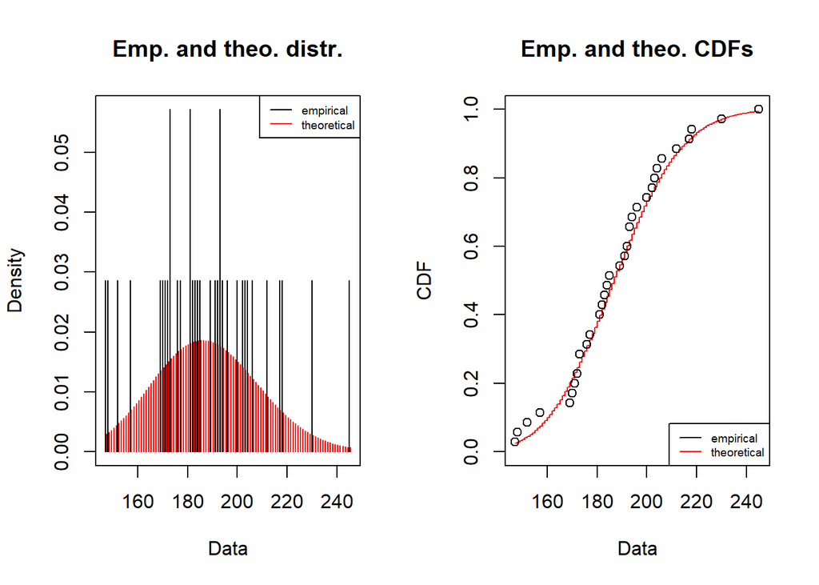

```r
plot(Internal_Fr_fit)
```

Ponowie kierując spojrzenie na rozkład dystrybuanty można uznać, że rozkład został w tym przypadku zdecydowanie dobrze przyporządkowany.

## 8.3 Rozkład strat

Będziemy sprawdzać dopasowanie funkcją fitdist, sprawdzamy dopasowanie rozkładu dotkliwości strat do rozkładów lnorm, exp oraz gamma. Dopasowanie metodą momentów (mme).

**Show and hide code**

```r
Internal_Fr2 <- fitdist(straty_Internal_Fr$straty, method="mme","lnorm")
Internal_Fr3 <- fitdist(straty_Internal_Fr$straty, method="mme","exp")
Internal_Fr4 <- fitdist(straty_Internal_Fr$straty, method="mme","gamma")
names_test = c("lnorm", "exp", "gamma")

Result_Internal_Fr<-gofstat(list(Internal_Fr2, Internal_Fr3,Internal_Fr4), fitnames=names_test)
Result_Internal_Fr$chisqpvalue
```

```
       lnorm          exp        gamma
3.619418e-01 6.260497e-30 4.274855e-01
```

**Show and hide code**

```r
Result_Internal_Fr$adtest
```

```
         lnorm            exp          gamma
"not computed" "not computed" "not computed"
```

**Show and hide code**

```r
Result_Internal_Fr$kstest
```

```
         lnorm            exp          gamma
"not rejected"     "rejected" "not rejected"
```

Tylko w przypadku kstest exp zostało odrzucone, reszta nieodrzucona. Z tego powodu zobaczmy to na wykresie.

- Dla lnorm:

**Show and hide code**

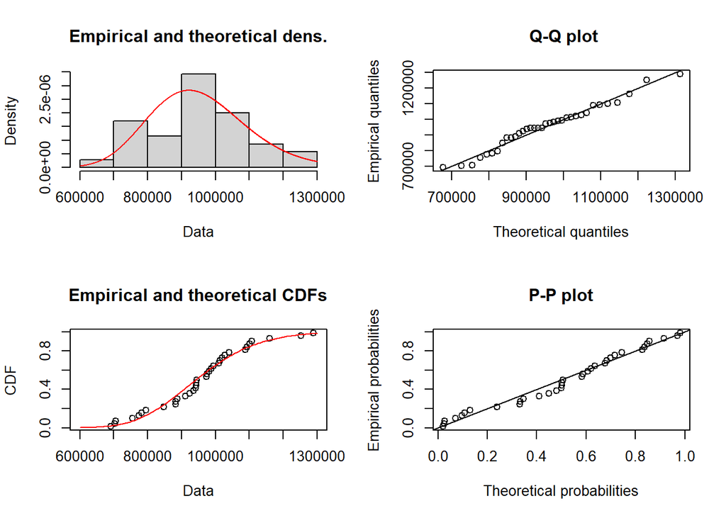

```r
plot(fitdist(straty_Internal_Fr$straty, "lnorm"))
```

- Dla gammy:

**Show and hide code**

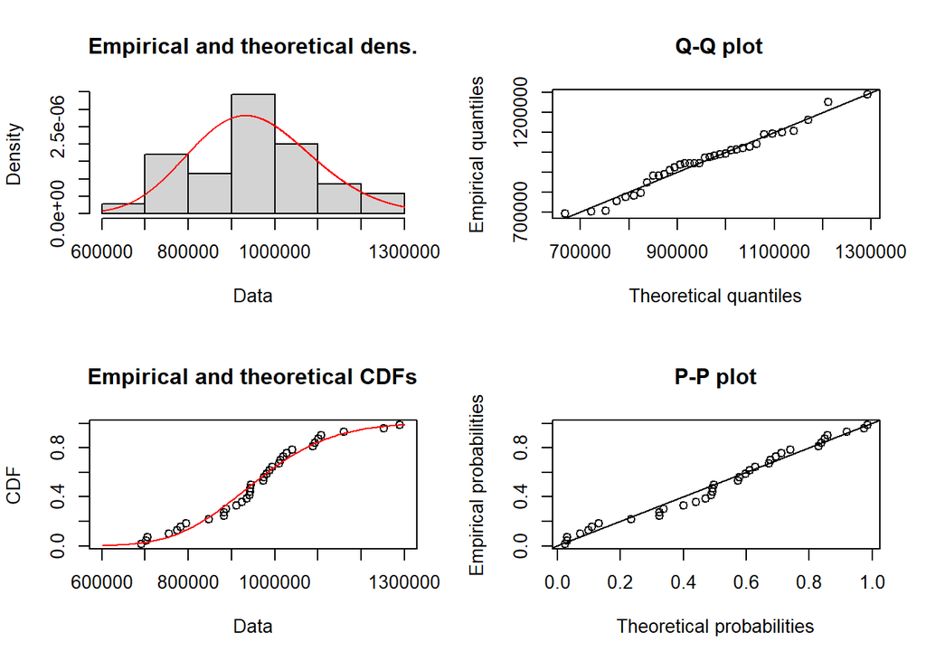

```r
plot(fitdist(straty_Internal_Fr$straty, "gamma"))
```

Wybieramy dopasowanie do rozkładu Lnorm.

## 8.4 Symulacja

Symulacja metodą Monte Carlo bazująca na dwóch wcześniej wybranych rozkładach - ujemny dwumianowy oraz Lnorm.

**Show and hide code**

```r
set.seed(123)

# Parametry nbinom
nbinom_params_int <- Internal_Fr_fit$estimate
size_param_int <- nbinom_params_int["size"]
mu_param_int <- nbinom_params_int["mu"]

# Parametry log-normal
lnorm_params_int <- Internal_Fr2$estimate
meanlog_int <- lnorm_params_int["meanlog"]
sdlog_int <- lnorm_params_int["sdlog"]
```

Parametry dla rozkładu ujemnego dwumianowego:  
size = 127.88  
mu = 187.59

Parametry dopasowania Lnorm:  
meanlog = 13.75  
sdlog = 0.15

Symulujemy 20000 scenariuszy rocznych strat. Do każdej symulacji wylosowano liczbę zdarzeń z rozkładu ujemnego dwumianowego oraz straty dla każdej szkody z rozkładu Lnorm.

**Show and hide code**

```r
symulacje_Internal_Fr <- replicate(n_sim, {
  liczba_zdarzen <- rnbinom(1, size = size_param_int, mu = mu_param_int)
  if (liczba_zdarzen == 0) return(0)
  sum(rlnorm(liczba_zdarzen, meanlog = meanlog_int, sdlog = sdlog_int))
})
```

Następnie na podstawie rozkładu symulowanego obliczamy OpVaR(99.9%) oraz OpES(99.9%).

**Show and hide code**

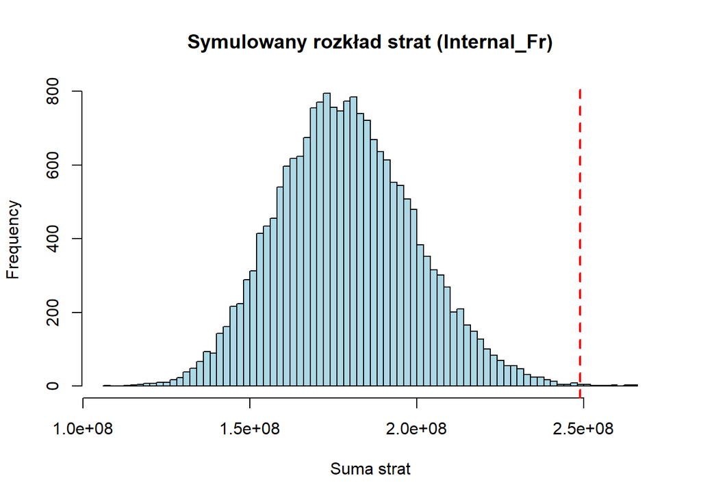

```r
OpVaR_999_Internal_Fr <- quantile(symulacje_Internal_Fr, 0.999)
OpES_999_Internal_Fr <- mean(symulacje_Internal_Fr[symulacje_Internal_Fr > OpVaR_999_Internal_Fr])

hist_Internal_Fr <- hist(symulacje_Internal_Fr, breaks = 100, col = "lightblue",
     main = "Symulowany rozkład strat (Internal_Fr)", xlab = "Suma strat")
abline(v = OpVaR_999_Internal_Fr, col = "red", lwd = 2, lty = 2)
```

**Show and hide code**

```r
cat("OpVaR (99.9%) = ", OpVaR_999_Internal_Fr, "\n")
```

```
OpVaR (99.9%) =  248757899
```

**Show and hide code**

```r
cat("OpES  (99.9%) = ", OpES_999_Internal_Fr, "\n")
```

```
OpES  (99.9%) =  256827842
```

# 9 Podsumowanie

**Show and hide code**

```r
## tabelka podsumowująca:
symulacje_df <- data.frame(
  Scenariusz = 1:n_sim,
  BussDist = symulacje_BussDist,
  Com_Ban = symulacje_Com_Ban,
  Damage = symulacje_Damage,
  Empl_Pract = symulacje_Empl_Pract,
  Execut_Del = symulacje_Execut_Del,
  External_Fr = symulacje_External_Fr,
  Internal_Fr = symulacje_Internal_Fr
)

# Dodanie kolumny z sumą strat dla każdego scenariusza
symulacje_df$Suma <- rowSums(symulacje_df[, -1])

# Podgląd

kable(head(symulacje_df,20), caption = "Tabela 1: Wielkość strat w kontekście scenariuszy:",
      align = "lrr", format = "markdown")
```

Tabela 1: Wielkość strat w kontekście scenariuszy:

| Scenariusz | BussDist | Com_Ban | Damage | Empl_Pract | Execut_Del | External_Fr | Internal_Fr | Suma |
| --- | --- | --- | --- | --- | --- | --- | --- | --- |
| 1 | 6917080 | 94598.64 | 705076.0 | 1819851757 | 194632.4 | 333050.1 | 184331097 | 2012427290 |
| 2 | 5383033 | 371385.46 | 2434410.6 | 1438947644 | 379336.8 | 556166.5 | 151994616 | 1600066593 |
| 3 | 8359773 | 530519.49 | 1777847.9 | 1706749084 | 106543.2 | 345487.5 | 167743227 | 1885612483 |
| 4 | 3443174 | 205427.59 | 980737.4 | 1708455958 | 236518.4 | 251985.0 | 175189718 | 1888763518 |
| 5 | 3592769 | 195328.05 | 855834.2 | 1491256983 | 111142.9 | 363771.3 | 182079688 | 1678455516 |
| 6 | 6057928 | 179887.46 | 860629.9 | 1449096908 | 292253.1 | 236028.0 | 156585821 | 1613309455 |
| 7 | 2538904 | 555769.42 | 1143244.0 | 1678534880 | 153781.4 | 393148.9 | 256290402 | 1939610129 |
| 8 | 4359605 | 69986.28 | 937136.2 | 1525754750 | 120227.8 | 321289.8 | 194143548 | 1725706543 |
| 9 | 6091471 | 258719.25 | 1810106.2 | 1653792314 | 286023.7 | 549700.2 | 178122742 | 1840911077 |
| 10 | 2415731 | 168848.38 | 1975121.3 | 1464718412 | 163178.9 | 225767.0 | 164932805 | 1634599863 |
| 11 | 5605828 | 497121.27 | 1536024.1 | 1553768316 | 324673.5 | 446978.9 | 150862830 | 1713041772 |
| 12 | 6168607 | 46165.29 | 1277879.8 | 1543858194 | 347818.4 | 426549.3 | 204251654 | 1756376868 |
| 13 | 3875506 | 405959.20 | 462543.1 | 1543998517 | 503464.2 | 540874.8 | 189172419 | 1738959283 |
| 14 | 7425381 | 152910.57 | 1485548.8 | 1461115310 | 221208.4 | 191472.7 | 176351274 | 1646943106 |
| 15 | 6196311 | 174610.09 | 1846280.7 | 1737793464 | 138790.3 | 811014.0 | 191319098 | 1938279569 |
| 16 | 2481833 | 172692.76 | 2381692.4 | 1511215225 | 344378.3 | 364630.1 | 210336693 | 1727297144 |
| 17 | 7191698 | 197534.41 | 1068030.5 | 1546720418 | 244725.5 | 443903.1 | 207162307 | 1763028617 |
| 18 | 2842821 | 229881.31 | 1317767.8 | 1619900680 | 279581.7 | 234618.0 | 189808006 | 1814613355 |
| 19 | 5647673 | 280588.61 | 937686.9 | 1601207703 | 72824.7 | 372156.1 | 154411843 | 1762930475 |
| 20 | 4208112 | 229235.15 | 1696356.5 | 1472081988 | 210770.8 | 229819.8 | 230334662 | 1708990945 |

**Show and hide code**

```r
library(tibble)
library(dplyr)

# Tabela ze wskaźnikami
tabela_oprisk <- tibble(
  linia_Biznesowa = c("Business Disruption", "Commercial Banking", "Damage to Assets",
                      "Employment Practices", "Execution & Delivery",
                      "External Fraud", "Internal Fraud"),
  OpVaR_999 = c(OpVaR_999_BussDist, OpVaR_999_Com_Ban, OpVaR_999_Damage,
                OpVaR_999_Empl_Pract, OpVaR_999_Execut_Del,
                OpVaR_999_External_Fr, OpVaR_999_Internal_Fr),
  OpES_999 = c(OpES_999_BussDist, OpES_999_Com_Ban, OpES_999_Damage,
               OpES_999_Empl_Pract, OpES_999_Execut_Del,
               OpES_999_External_Fr, OpES_999_Internal_Fr)
) %>%
  mutate(across(OpVaR_999:OpES_999, round, 2))


# Wyświetlenie tabeli
library(knitr)

kable(tabela_oprisk, caption = "Tabela 2: Wskaźniki OpVaR i OpES dla poszczególnych liniii biznesowych",
      align = "lrr", format = "markdown")
```

Tabela 2: Wskaźniki OpVaR i OpES dla poszczególnych liniii biznesowych

| linia_Biznesowa | OpVaR_999 | OpES_999 |
| --- | --- | --- |
| Business Disruption | 15602967.6 | 17364747.5 |
| Commercial Banking | 865645.1 | 958487.2 |
| Damage to Assets | 3144709.9 | 3354405.4 |
| Employment Practices | 2087657615.4 | 2122266963.3 |
| Execution & Delivery | 667818.2 | 717884.6 |
| External Fraud | 830351.2 | 890326.5 |
| Internal Fraud | 248757899.3 | 256827842.2 |

Najniższą stratę posiada Execution & Delivery. Problemy związane z dostawą choć mogą być kosztowne jak widzimy są najmniejszym zmartwieniem dla banków.

Porównując wartości dla OpVaru 999 widzimy jak z wielkim ryzykiem straty wiąże się praca banków. Powinny mieć one ogromne poduszki finansowe lub jakieś innego typu zabezpieczenia, które pomogły by w przypadku nasilenia się problemów.

**Show and hide code**

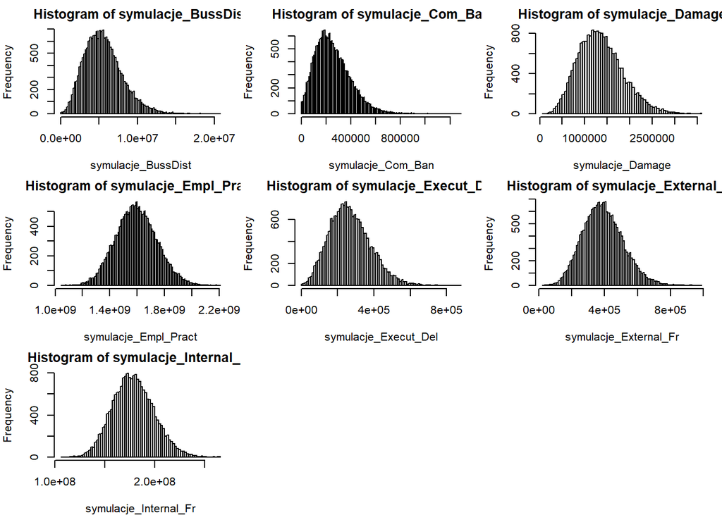

```r
library(gridExtra)

par(mfrow = c(3, 3), mar = c(4, 4, 2, 1))
plot(hist_BussDist)
plot(hist_Com_Ban)
plot(hist_Damage)
plot(hist_Empl_Pract)
plot(hist_Execut_Del)
plot(hist_External_Fr)
plot(hist_Internal_Fr)
```

**Wnioski**

Niejednorodność rozkładów strat: Większość rozkładów strat wykazuje charakter prawoskośny, co może sugerować, że większość strat jest stosunkowo niewielka, ale niektóre incydenty mogą powodować wyjątkowo duże straty. To podkreśla, jak istotne jest monitorowanie i modelowanie ryzyka skrajnych zdarzeń.